# Model Validation for Categorical Response and dealing with Imbalanced Data

Ping-Yang Chen

```r
install.packages(c("ggplot2", "GGally", "cvms", "tibble", "glmnet", "smotefamily", "pracma"))
```

# Model Validation for Categorical Response

以信用卡違約記錄資料作為範例，讀取資料並整理成迴歸分析所需格式。針對類別型變數，在 R 中請自行將欄位更改為 `factor` 型態。

```r
defUrl <- 'https://raw.githubusercontent.com/PingYangChen/BDA_Course_R_Code/refs/heads/main/sample_data/Default.csv'
defDf <- read.csv(defUrl)
defDf$default <- as.factor(defDf$default)
defDf$student <- as.factor(defDf$student)
```

大略檢視前 6 筆資料

```r
head(defDf, 6)
```

```
##   default student   balance    income
## 1      No      No  729.5265 44361.625
## 2      No     Yes  817.1804 12106.135
## 3      No      No 1073.5492 31767.139
## 4      No      No  529.2506 35704.494
## 5      No      No  785.6559 38463.496
## 6      No     Yes  919.5885  7491.559
```

作圖快速檢視資料各變數的分佈形態，以及變數之間的關聯與差異。圖中顯示解釋變數 `balance` 在反應變數 `default` 不同時有數值分布上的差異，且兩個解釋變數 `balance` 與 `income` 之間有一個低度負相關。

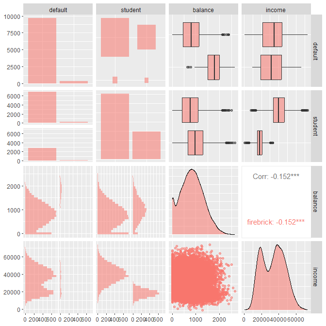

以下使用 Logistic regression 分析信用卡違約記錄資料，同上一篇，在此也使用 **glmnet** 套件。

```r
library(glmnet)
```

先將資料整理成 `glmnet` 所需格式：`model.matrix`。

- 反應變數可直接從資料中擷取，並轉成 `0`、`1` 二元數字。
- 解釋變數則透過 `model.matrix` 函數與 R 模型語法快速整理**（記得刪除截距項）**。

```r
# Create the Binary Response Variable
y <- as.numeric(defDf$default) - 1
# Create model matrix
modelmat <- model.matrix(default ~ ., data = defDf)[,-1] # Remove intercept part
```

以 `glmnet` 建立 Logistic regression model，並透過 `predict` 計算模型配適值。

```r
# fit logistic regression model
glm_fit <- glmnet(modelmat, y, family = "binomial", alpha = 0, lambda = 0)
y_fit <- (predict(glm_fit, modelmat, type = "response") > 0.5)
```

## Confusion Matrix Definition

自行定義混淆矩陣函數（[參考資料](https://en.wikipedia.org/wiki/Receiver_operating_characteristic)）

多併一組 `uniqueY` 再數數量，確保每個類別都至少有 1 個 最後將多數的 1 扣掉，讓 table 能輸出所有類別的計數 (包含 0)

```r
confusion <- function(trueY, predY) {
  uniqueY <- unique(trueY)
  ncateg <- length(uniqueY)
  confmat <- matrix(0, ncateg, ncateg)
  for (i in 1:ncateg) {
    loc <- which(trueY == uniqueY[i])
    # 多併一組 uniqueY 再屬數量，確保每個類別都至少有 1 個
    # 最後將多數的 1 扣掉，讓 table 能輸出所有類別的計數 (包含 0)
    pred_count <- table(c(predY[loc], uniqueY)) - 1
    confmat[i,] <- pred_count
  }
  confmat <- as.table(confmat)
  dimnames(confmat) <- list("target" = uniqueY, "prediction" = uniqueY)
  return(confmat)
}
```

計算模型配適的分類表現

```r
library(tibble)
library(cvms)
```

```r
# Compute Confusion Matrix
confmat <- confusion(y, y_fit)
print(confmat)
```

```
##       prediction
## target    0    1
##      0 9627   40
##      1  228  105
```

```r
# Calculate Classification Rates
acc <- 100*sum(diag(confmat))/sum(confmat)
tpr <- 100*confmat[2,2]/sum(confmat[2,])
tnr <- 100*confmat[1,1]/sum(confmat[1,])
print(data.frame(ACC = acc, TPR = tpr, TNR = tnr))
```

```
##     ACC      TPR      TNR
## 1 97.32 31.53153 99.58622
```

另外，套件 **cvms** 及 **tibble** 可用於視覺化混淆矩陣

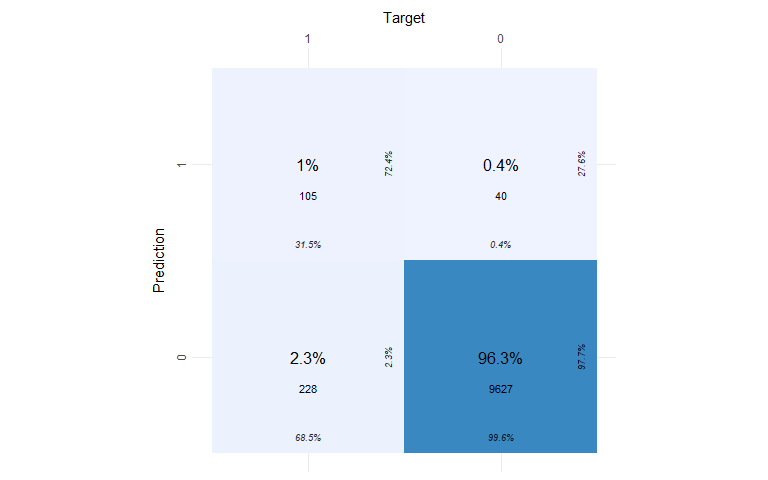

```r
library(cvms)
library(tibble)
plot_confusion_matrix(as_tibble(confmat),
                      target_col = "target",
                      prediction_col = "prediction",
                      counts_col = "n")
```

## Cross-validation for Classification Model

交互驗證的方式與上一篇類似，差別只在於結果檢視與模型預測表現以混淆矩陣計算

```r
# Make CV-folds by yourself
library(pracma)
```

1. 切分訓練測試集（思考可以精進的方式）

```r
# Implement 10-fold CV
n <- length(y)
nfold <- 10 # set number of folds
# Always remember to set seed before actions with randomness involved!!
seed <- 1
set.seed(seed)
# Create belonging folds for each data point
# by randomly permuting the index of folds.
folds <- pracma::randperm(
  rep(1:nfold, time = ceiling(n/nfold))[1:n]
)
# View the distribution of testing data sizes in each fold
table(folds)
```

```
## folds
##    1    2    3    4    5    6    7    8    9   10
## 1000 1000 1000 1000 1000 1000 1000 1000 1000 1000
```

2. 執行交互驗證

```r
# Create space for storing predicted values of 10-fold CV
y_cv <- numeric(n)
# Start 10-fold CV
for (k in 1:nfold) {
  # Get data id for training and testing
  train_id <- which(folds != k)
  test_id <- which(folds == k)
  # Get training data (X and y)
  train_x <- modelmat[train_id,]
  train_y <- y[train_id]
  # Get testing data (X)
  test_x <- modelmat[test_id,]
  test_y <- y[test_id]
  # Fit Logistic model with training data
  lm_fold <- glmnet(train_x, train_y, family = "binomial", alpha = 0, lambda = 0)
  # Get prediction of the testing data
  yhat_fold <- (predict(lm_fold, test_x, type = "response") > 0.5)
  # Allocate those predicted values into the corresponding fold
  y_cv[test_id] <- yhat_fold
}
```

3. 計算交互驗證下的模型分類表現

```r
# Compute Confusion Matrix
confmat_cv <- confusion(y, y_cv)
print(confmat_cv)
```

```
##       prediction
## target    0    1
##      0 9627   40
##      1  227  106
```

```r
# Calculate Classification Rates
acc_cv <- 100*sum(diag(confmat_cv))/sum(confmat_cv)
tpr_cv <- 100*confmat_cv[2,2]/sum(confmat_cv[2,])
tnr_cv <- 100*confmat_cv[1,1]/sum(confmat_cv[1,])
print(data.frame(ACC = acc_cv, TPR = tpr_cv, TNR = tnr_cv))
```

```
##     ACC      TPR      TNR
## 1 97.33 31.83183 99.58622
```

# Handling Imbalanced Data

本文使用的信用卡違約記錄資料為不平衡資料，這種資料常見的問題包含

- 分類器的 TPR 過低
- 隨機切分資料進行交互驗證時，可能導致某一組訓練資料只包含一種分類的資料（**如何避免？**）

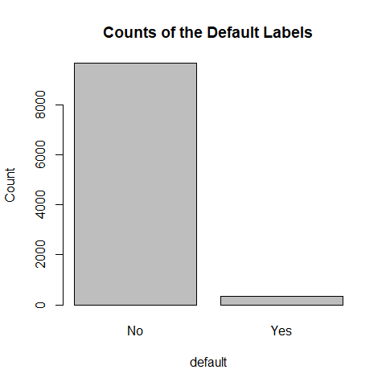

本文介紹常用的不平衡資料處理方法：

1. 建模後：控制分類器決策
2. 建模時：考慮類別權重
3. 建模前：資料重抽樣

## Cutoff Manipulation

以二元 Logistic regression model 為例，模型假設 $Y\sim Ber(\mu)$，此機率為解釋變數線性組合的 inverse-logit 轉換
$$\mu=P(Y = 1\mid \mathbf{X} = \mathbf{x}) =
\frac{\exp{\{\mathbf{x}^\top\boldsymbol{\beta}\}}}{1+\exp{\{\mathbf{x}^\top\boldsymbol{\beta}\}}}$$

實務上，若要判斷所輸入的測試資料 $\mathbf{x}$ 對應的類別 $\hat{Y}$，仍須主觀地給予模型輸出機率值一個分類門檻（cutoff）

$$\hat{Y} = I\left[\hat{P}(Y = 1\mid \mathbf{X} = \mathbf{x}) > C
\right]$$
一般而言，若無任何主觀意見，通常設定 $C = 0.5$，但此未必是最合適（讓模型分類表現最佳）的門檻值。

若要找最合適的門檻值，可以嘗試多種 cutoff 設定，並記錄不同 cutoff 之下的 true positive rate（TPR）及 false positive rate（FPR），繪製 receiver operating characteristic（ROC）曲線，找到最能平衡 TPR 及 FPR 的最佳 cutoff。

另一種方式是，在不同 cutoff 設定之下，計算由 TPR 及 FPR 衍生的總合指標，例如 F1-score
$$F_1 =
\frac{2TP}{2TP + FP + FN}$$
，挑出使 F1-score 最高的 cutoff。

```r
cutoffs <- seq(0, 1, length = 101)
```

```r
# fit logistic regression model
glm_fit <- glmnet(modelmat, y, family = "binomial", alpha = 0, lambda = 0)
# Create space for storing FPR, TPR and F1 score
scoreMat <- matrix(0, length(cutoffs), 3)
colnames(scoreMat) <- c("FPR", "TPR", "F1")
# Run for each cutoff and calculate the corresponding FPR, TPR and F1 score
for (i in 1:length(cutoffs)) {
  y_glm <- (predict(glm_fit, modelmat, type = "response") > cutoffs[i])
  # Compute Accuracy using confusion matrix
  cm_glm <- confusion(y, y_glm)
  tpr_glm <- 100*cm_glm[2,2]/sum(cm_glm[2,])
  fpr_glm <- 100 - 100*cm_glm[1,1]/sum(cm_glm[1,])
  f1_glm <- 2*cm_glm[2,2]/(2*cm_glm[2,2] + cm_glm[1,2] + cm_glm[2,1])
  scoreMat[i,] <- c(fpr_glm, tpr_glm, f1_glm)
}
```

繪製 receiver operating characteristic （ROC）曲線。一般而言，選擇靠近 ROC 曲線左上緣的 cutoff，但仍存在分析者的主觀認定。

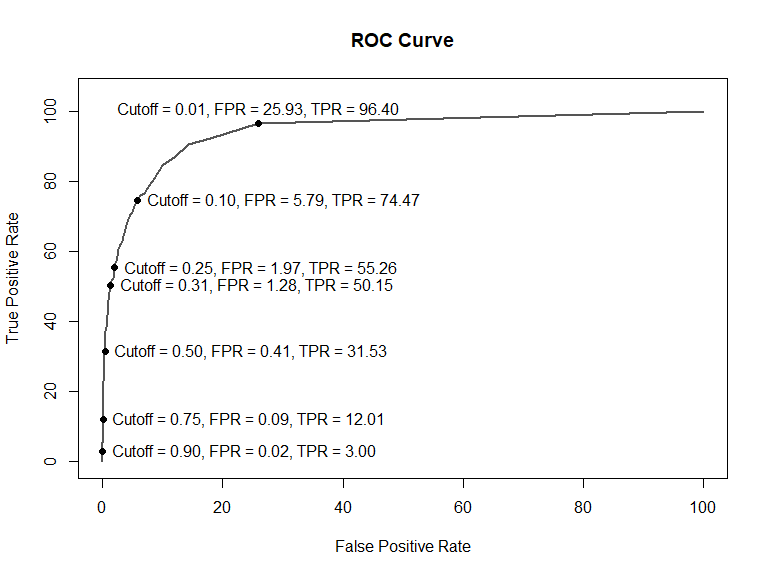

```r
plot(scoreMat[,1:2], type = "l", lwd = 2, ylim = c(-.5, 105), col = "#555555",
     ylab = "True Positive Rate", xlab = "False Positive Rate", main = "ROC Curve")
for (k in c(2, 11, 26, 51, 76, 91, which.max(scoreMat[,3]))) {
  points(scoreMat[k,1], scoreMat[k,2], pch = 16)
  if (k == 2) { tpos = 3 } else { tpos = 4 }
  text(scoreMat[k,1], scoreMat[k,2],
       sprintf("Cutoff = %.2f, FPR = %.2f, TPR = %.2f",
               cutoffs[k], scoreMat[k,1], scoreMat[k,2]),
       pos = tpos)
}
```

繪製 cutoff vs. F1-score 曲線。較直接，可選擇對應 F1-score 最高的 cutoff。

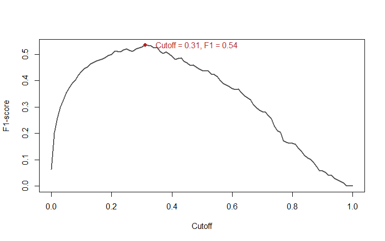

```r
plot(cutoffs, scoreMat[,3], type = "l", lwd = 2, col = "#555555", xlab = "Cutoff", ylab = "F1-score")
points(cutoffs[which.max(scoreMat[,3])], max(scoreMat[,3]), pch = 16, col = "firebrick")
text(cutoffs[which.max(scoreMat[,3])], max(scoreMat[,3]),
     sprintf("   Cutoff = %.2f, F1 = %.2f", cutoffs[which.max(scoreMat[,3])], max(scoreMat[,3])),
     col = "firebrick", pos = 4)
```

計算最佳 F1-score 對應的 Cutoff 於模型配適的分類表現

```r
mc_y_glm <- (predict(glm_fit, modelmat, type = "response") > cutoffs[which.max(scoreMat[,3])])

# Compute Confusion Matrix
confmat_mc <- confusion(y, mc_y_glm)
print(confmat_mc)
```

```
##       prediction
## target    0    1
##      0 9543  124
##      1  166  167
```

```r
# Calculate Classification Rates
acc_mc <- 100*sum(diag(confmat_mc))/sum(confmat_mc)
tpr_mc <- 100*confmat_mc[2,2]/sum(confmat_mc[2,])
tnr_mc <- 100*confmat_mc[1,1]/sum(confmat_mc[1,])
print(data.frame(ACC = acc_mc, TPR = tpr_mc, TNR = tnr_mc))
```

```
##    ACC      TPR      TNR
## 1 97.1 50.15015 98.71729
```

## Weighted Logistic Regression

第二種方式是在建模時，於 loss function（objective function）中加入類別權重，使得模型建立時，讓少數類別被分類錯誤的 loss 加重，迫使模型估計偏向加強對少數類別的分類準確性，做法如下。

建立權重，給予少數類別較大的權重，多數類別較小的權重

```r
# Create the weight vector based on the distribution of the binary response
wt <- numeric(length(y))
wt[y == 0] <- 1 - sum(1 - y)/length(y)
wt[y == 1] <- 1 - sum(y)/length(y)
```

以二元 Weighted logistic regression model 為例，使用 `glmnet` 透過設定 `weights = wt` 加入權重建立模型，並透過 `predict` 計算模型配適值。

```r
# fit logistic regression model
wglm_fit <- glmnet(modelmat, y, family = "binomial",
                   alpha = 0, lambda = 0, weights = wt)
y_wglm <- (predict(wglm_fit, modelmat, type = "response") > 0.5)
```

計算模型配適的分類表現

```r
# Compute Confusion Matrix
cm_wglm <- confusion(y, y_wglm)
print(cm_wglm)
```

```
##       prediction
## target    0    1
##      0 8355 1312
##      1   35  298
```

```r
# Calculate Classification Rates
acc_wglm <- 100*sum(diag(cm_wglm))/sum(cm_wglm)
tpr_wglm <- 100*cm_wglm[2,2]/sum(cm_wglm[2,])
tnr_wglm <- 100*cm_wglm[1,1]/sum(cm_wglm[1,])
print(data.frame(ACC = acc_wglm, TPR = tpr_wglm, TNR = tnr_wglm))
```

```
##     ACC      TPR      TNR
## 1 86.53 89.48949 86.42805
```

## Synthesized Minority Oversampling Technique (SMOTE)

在建模前處理資料不平衡問題，可進行資料重抽樣，常用的手法包含 up-sampling 及 down-sampling，以及較為整合應用之 SMOTE 方法。在 R 中，可使用套件 **smotefamily** 來執行資料重抽樣。

```r
library(smotefamily)
```

使用基本 `SMOTE` 方法做為範例，輸入 model matrix 及反應變數

```r
# Use SMOTE for for Imbalanced Data
defDfSmoteObj <- SMOTE(data.frame(modelmat), y)
nrow(defDfSmoteObj$data)
```

```
## [1] 19324
```

可見 `SMOTE` 將資料擴增為 19324 筆，相較於原始資料多出 9324 筆。再將重抽樣的資料整理成 `glmnet` 須要的輸入格式。

```r
# Remove the final response column 'class' generated by SMTOE
modelmat_smote <- as.matrix(defDfSmoteObj$data[,-ncol(defDfSmoteObj$data)])
# Transfer format for the response column 'class'
y_smote <- as.numeric(defDfSmoteObj$data$class)
```

輸入 **SMOTE 重抽樣資料**，以 `glmnet` 建立 Logistic regression model。於計算模型配適值時，輸入**原始資料**，透過 `predict` 輸出即可。

```r
# fit logistic regression model
smote_glm_fit <- glmnet(modelmat_smote, y_smote, family = "binomial",
                        alpha = 0, lambda = 0)
smote_y_glm <- (predict(smote_glm_fit, modelmat, type = "response") > 0.5)
```

計算模型配適的分類表現

```r
# Compute Confusion Matrix
rs_cm_glm <- confusion(y, smote_y_glm)
print(rs_cm_glm)
```

```
##       prediction
## target    0    1
##      0 8513 1154
##      1   41  292
```

```r
# Calculate Classification Rates
rs_acc <- 100*sum(diag(rs_cm_glm))/sum(rs_cm_glm)
rs_tpr <- 100*rs_cm_glm[2,2]/sum(rs_cm_glm[2,])
rs_tnr <- 100*rs_cm_glm[1,1]/sum(rs_cm_glm[1,])
print(data.frame(ACC = rs_acc, TPR = rs_tpr, TNR = rs_tnr))
```

```
##     ACC      TPR      TNR
## 1 88.05 87.68769 88.06248
```

# Concluding Remarks

整理本篇所介紹各方法的模型配適分類表現（交互驗證之結果可自行驗證）

```r
methodSummary <- data.frame(
  ACC = c(acc, acc_mc, acc_wglm, rs_acc),
  TPR = c(tpr, tpr_mc, tpr_wglm, rs_tpr),
  TNR = c(tnr, tnr_mc, tnr_wglm, rs_tnr)
)
rownames(methodSummary) <- c("GLM", "Best F1", "WGLM", "SMOTE-GLM")
print(methodSummary)
```

```
##             ACC      TPR      TNR
## GLM       97.32 31.53153 99.58622
## Best F1   97.10 50.15015 98.71729
## WGLM      86.53 89.48949 86.42805
## SMOTE-GLM 88.05 87.68769 88.06248
```